# Birds 00: Spatial Analysis

Arne Wenzel

June 2019

### Prerequisites

[Data download link](https://github.com/KwnLi/spatial/blob/master/Data.zip?raw=true)

```r
library(raster)
library(rgdal)
library(landscapemetrics)
library(dplyr)
library(vegan)
library(tidyverse)
library(berryFunctions)
library(cowplot)
library(ggplot2)
```

### Import raster

The raster I import is a map of the entire Bangalore study region. It does contain both the north and the south transect. However, at the moment 2 of my sites fall outside of the classification.

```r
bgl <- raster(readGDAL("sentinel_reclassified_2.tif"))
```

For later use I also need to specify the land use classes in the raster

```r
classes <- c("grey", "green" ,"crop", "fallow", "barren", "water")
```

### Import site locations

I will build up the points from scratch, since I had issues while trying to directly import shape files from QGIS.

All the information I need is within my “site_info.csv” file. All site related information are stored inside (location, ids, name, etc.). I use a classical data.frame and set the site_ids as rownames, this works better with the spatial packages than a tidy workflow.

```r
site_info <- read.csv("20190515_site_infos.csv", sep = ";",dec=".")
rownames(site_info) = site_info$site_id
```

Next I create my spatial point data frame. For that I need to merge the point coordinates with some additional point data (like the name, transect, area). Furthermore I have to specify the Coordinate system (WGS84 /UTM zone 43n).

```r
CountPts <- SpatialPointsDataFrame(site_info[, 9:10], # the coordinates
                                   site_info[, 1:6], # the data
                                   proj4string = CRS(
                                     "+proj=utm +zone=43 +datum=WGS84 +units=m +no_defs+ellps=WGS84+towgs84=0,0,0")) # coordinate system
```

### Plot raster and points

Just as a rough overview I want to plot the raster and my site locations. The resulting map is very small - but nevertheless you can clearly see the north and the south transect. Note the two sites in the south which are outside the transects eastern boundary.

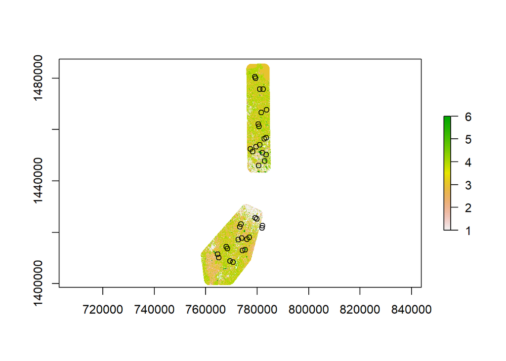

```r
plot(bgl)
points(CountPts)
```

### Create buffers

I want to analyse the landscape around my sites within circular buffers of different radii. To do that I first have to create the buffer polygons. I will use radii of 100, 500, 1000 and 1500 m around the site points. Since some buffers overlap I have to specfiy `dissolve = FALSE`.

```r
# Create buffer polygons
bf100_ply   <- buffer(CountPts, width = 100, dissolve = F)
bf500_ply   <- buffer(CountPts, width = 500, dissolve = F)
bf1000_ply  <- buffer(CountPts, width = 1000, dissolve = F)
bf1500_ply  <- buffer(CountPts, width = 1500, dissolve = F)
```

Next I can use the created polygons to clip the large landscape raster. Basicially, I end up with 36 little landscapes for each of my 4 buffer distances. They are saved in a list object.

```r
# Cut raster by buffers
bf100_ras <- list()
for(i in 1:36) {
  bf100_ras[i] <- crop(bgl, bf100_ply[i,])
  bf100_ras[i] <- mask(bf100_ras[[i]], bf100_ply[i,])
}


bf500_ras <- list()
for(i in 1:36) {
  bf500_ras[i] <- crop(bgl, bf500_ply[i,])
  bf500_ras[i] <- mask(bf500_ras[[i]], bf500_ply[i,])
}

bf1000_ras <- list()
for(i in 1:36) {
  bf1000_ras[i] <- crop(bgl, bf1000_ply[i,])
  bf1000_ras[i] <- mask(bf1000_ras[[i]], bf1000_ply[i,])
}

bf1500_ras <- list()
for(i in 1:36) {
  bf1500_ras[i] <- crop(bgl, bf1500_ply[i,])
  bf1500_ras[i] <- mask(bf1500_ras[[i]], bf1500_ply[i,])
}
```

Finally, I still have to specify the names of my 36 little landscapes - the site-ids, of course.

```r
# Set the names of the rasters in the list (my site ids)
names(bf100_ras)  = CountPts@data$site_id
names(bf500_ras)  = CountPts@data$site_id
names(bf1000_ras) = CountPts@data$site_id
names(bf1500_ras) = CountPts@data$site_id
```

Ok, just out of fun (and to get an impression): let us plot the first 4 of my little 36 landscapes for the 500 m radius buffers. If I want I could also change the colors to something more appropriate, but I just go with the default for now.

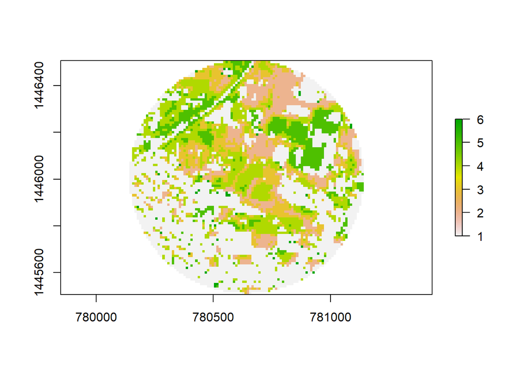

```r
plot(bf500_ras[[1]])
```

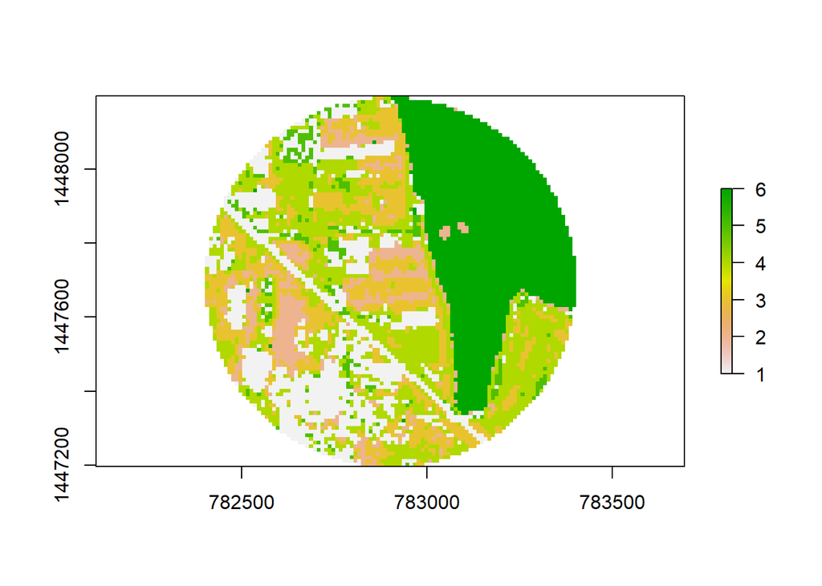

```r
plot(bf500_ras[[2]])
```

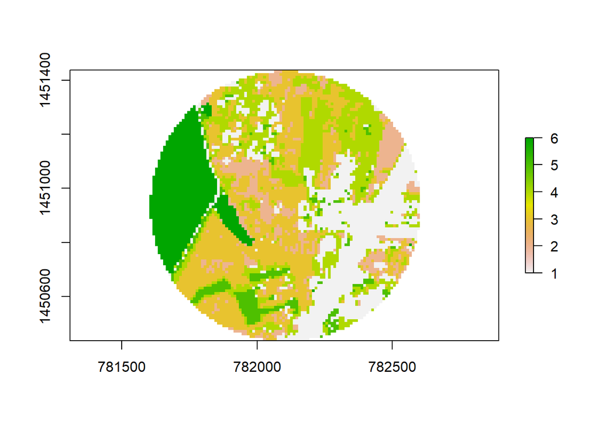

```r
plot(bf500_ras[[3]])
```

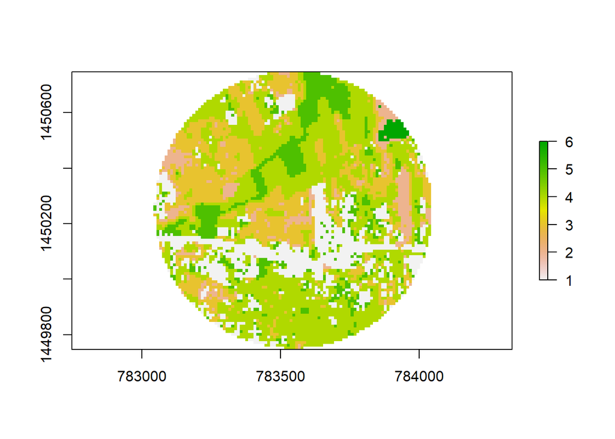

```r
plot(bf500_ras[[4]])
```

### Extract spatial data

Now I have to extract the “data” from my 36 little landscape. Basically I want to know how many pixels (size is 10 x 10 m) belong to each landuse class. With that I can later calculate proportional cover. I can do that with the `extract()` function from the raster package. Note that there is another `extract()` in the tidyr package.

```r
# Extract all pixel values of the raster within buffers around sites/points
bf100_px  <- raster::extract(bgl, CountPts, buffer = 100)
bf500_px  <- raster::extract(bgl, CountPts, buffer = 500)
bf1000_px <- raster::extract(bgl, CountPts, buffer = 1000)
bf1500_px <- raster::extract(bgl, CountPts, buffer = 1500)
```

#### Pixel counts per class

Now I have all the raw pixel values. But I want to count them for each class seperatetly and get a table with the result. For this I set up two functions (following some code I got from Kevin Li). The first function counts the pixel per class and the second takes the results and put them into a table. Both functions need the lapply() command to work, since the previous spatial objects I created are list objects. I will use these functions in the next steps. Note that these functions do not return a tibble but a matrix.

```r
# Function: Counts the pixels per class per buffer (needs lapply() to work)
count_class_px <- function(raster_values) {
  levels = 1:length(classes)
  px <- c()
  for(i in 1:length(levels)) {
    px[i] <- sum(raster_values == levels[i], na.rm = T)
  }
  names(px) = classes
  return(px)
}

# Function: table of class pixel counts
table_class_count <- function(raster_values) {
  px_list <- lapply(raster_values,count_class_px )
  px_mat <- matrix(unlist(px_list), nrow = length(px_list), byrow = T)
  dimnames(px_mat) = list(CountPts@data$site_id, names(px_list[[1]]))
  return(px_mat)
}
```

#### Proportional cover per class

Next to get basic pixel counts I also want to have the proportions of each class. For this I slightly tweak the functions above.

```r
# Function: Percentage of each class per buffer (needs lapply() to work)
perc_class_px <- function(raster_values) {
  levels = 1:length(classes)
  px <- c()
  for(i in 1:length(levels)) {
    px[i] <- sum(raster_values == levels[i], na.rm = T)
  }
  perc_px <- 100 * px / (sum(px))
  names(perc_px) = classes
  return(perc_px)
}

# Function: table of class percentages
table_class_perc <- function(raster_values) {
  perc_list <- lapply(raster_values, perc_class_px)
  perc_mat <- matrix(unlist(perc_list), nrow = length(perc_list), byrow = T)
  dimnames(perc_mat) = list(CountPts@data$site_id, names(perc_list[[1]]))
  return(perc_mat)
}
```

### Landscape composition

Ok great, with the above functions I can now calculate the landscape compositon, i.e. the proportional share of each landuse class per indiviual buffer/radius.

```r
composition <- cbind(
  table_class_perc(bf100_px),
  table_class_perc(bf500_px),
  table_class_perc(bf1000_px),
  table_class_perc(bf1500_px)
)

colnames(composition) = c(
  paste(classes, rep("_100",5), sep = ""),
  paste(classes, rep("_500",5), sep = ""),
  paste(classes, rep("_1000",5), sep = ""),
  paste(classes, rep("_1500",5), sep = "")
)

head(composition)
```

```
##         grey_100 green_100 crop_100 fallow_100 barren_100 water_100
## N_U01a  4.140127 10.509554 25.15924  57.324841  2.8662420  0.000000
## N_U01b  6.962025 34.493671 50.63291   7.594937  0.3164557  0.000000
## N_U02a 12.101911 24.203822 51.91083  10.509554  1.2738854  0.000000
## N_U02b  8.974359 14.743590 56.41026  19.871795  0.0000000  0.000000
## N_U03a 26.923077  4.166667 34.93590  29.807692  2.8846154  1.282051
## N_U03b  0.000000  4.126984 38.41270  56.507937  0.9523810  0.000000
##         grey_500 green_500 crop_500 fallow_500 barren_500   water_500
## N_U01a 44.940817 12.052946 12.57477   19.76581  10.054728  0.61092020
## N_U01b 19.128884  7.755986 17.79165   24.47784   3.604177 27.24146714
## N_U02a 22.352342 10.412424 28.33503   21.09216   4.722505 13.08553971
## N_U02b 18.091477  6.510383 22.38502   40.96063  11.275322  0.77716907
## N_U03a 28.615149  4.106095 28.28360   33.26957   5.368528  0.35705177
## N_U03b  6.133876  6.553830 41.37185   43.66251   2.265207  0.01272588
##        grey_1000 green_1000 crop_1000 fallow_1000 barren_1000 water_1000
## N_U01a 45.841559  15.525696  12.73324    20.32096    5.075463  0.5030886
## N_U01b 19.814803   7.099217  19.76389    35.77611    4.047604 13.4983771
## N_U02a 26.669638   9.861845  22.12389    18.34851    5.363851 17.6322659
## N_U02b 20.920609   6.331572  18.98835    45.18368    7.595340  0.9804546
## N_U03a 17.855096   9.136054  32.87706    35.42370    4.485261  0.2228306
## N_U03b  9.036797   7.951362  35.39598    43.39827    3.861090  0.3565062
##        grey_1500 green_1500 crop_1500 fallow_1500 barren_1500 water_1500
## N_U01a 47.126225  12.454202  12.91395    22.00563    5.009124  0.4908687
## N_U01b 21.931313   8.012957  17.65538    41.17514    4.472545  6.7526663
## N_U02a 28.502921   7.681317  21.39876    24.51656    5.474530 12.4259099
## N_U02b 25.135112   5.758185  18.09089    41.70510    8.395348  0.9153674
## N_U03a 19.445663  10.890081  31.13089    33.70449    4.383197  0.4456769
## N_U03b  9.463874   7.145450  40.73574    39.26513    3.112524  0.2772818
```

### Landscape diversity

To calculate landscape diversity indicies I use the `diversity()` function of the vegan package. This function needs to be called on a community matrix with sites as rows and the counts of the landuse classes in the columns. Now, I can use the pixel count function `table_class_count()` I created above.

```r
diversity <- cbind(diversity(table_class_count(bf100_px)),
                   diversity(table_class_count(bf100_px), "simpson"),
                   diversity(table_class_count(bf500_px)),
                   diversity(table_class_count(bf500_px), "simpson"),
                   diversity(table_class_count(bf1000_px)),
                   diversity(table_class_count(bf1000_px), "simpson"),
                   diversity(table_class_count(bf1500_px)),
                   diversity(table_class_count(bf1500_px), "simpson"))

colnames(diversity) = paste(rep(c("shannon", "simpsons"),4),
                           c("_100","_100", "_500", "_500","_1000","_1000",
                             "_1500", "_1500"), sep ="")

head(diversity)
```

```
##        shannon_100 simpsons_100 shannon_500 simpsons_500 shannon_1000
## N_U01a   1.1365818    0.5945069    1.457767    0.7184766     1.410903
## N_U01b   1.1112455    0.6140242    1.640373    0.7903136     1.596839
## N_U02a   1.2316375    0.6460911    1.666300    0.7950668     1.688706
## N_U02b   1.1426611    0.6125082    1.471655    0.7323714     1.417559
## N_U03a   1.3720358    0.7138807    1.389597    0.7228538     1.412435
## N_U03b   0.8659431    0.5313379    1.163712    0.6296247     1.294170
##        simpsons_1000 shannon_1500 simpsons_1500
## N_U01a     0.7056414     1.387519     0.6947662
## N_U01b     0.7687844     1.527510     0.7382103
## N_U02a     0.8025672     1.647650     0.7885238
## N_U02b     0.7061467     1.436461     0.7197154
## N_U03a     0.7241821     1.450943     0.7378736
## N_U03b     0.6703792     1.268894     0.6648462
```

### Landscape configuration

For the landscape configuration metrics I use functions of the landscapemetrics package. These functions return a tibble and the calculated values are found in the last column (…$value). All metrics work on the landscape level, so they return one value for each of my sites/landscape. See the corresponding help pages for the used function for a detailed discription of each of the metrics.

But before I can start I need to omit the two sites for which I still miss the landscape data. The landscapemetric package does not like NAs.

```r
bf100_ras[c(9:10)]  <- NULL
bf500_ras[c(9:10)]  <- NULL
bf1000_ras[c(9:10)] <- NULL
bf1500_ras[c(9:10)] <- NULL
```

```r
configuration <- tibble(
  mn_p_area_100  = lsm_l_area_mn(bf100_ras)$value, # mean patch area
  mn_p_area_500  = lsm_l_area_mn(bf500_ras)$value,
  mn_p_area_1000 = lsm_l_area_mn(bf1000_ras)$value,
  mn_p_area_1500 = lsm_l_area_mn(bf1500_ras)$value,
  mn_para_100  = lsm_l_para_mn(bf100_ras)$value, # mn paraemter-to-area-ratio
  mn_para_500  = lsm_l_para_mn(bf500_ras)$value,
  mn_para_1000 = lsm_l_para_mn(bf1000_ras)$value,
  mn_para_1500 = lsm_l_para_mn(bf1500_ras)$value,
  mn_shp_100  = lsm_l_shape_mn(bf100_ras)$value, # mn shape index
  mn_shp_500  = lsm_l_shape_mn(bf500_ras)$value,
  mn_shp_1000 = lsm_l_shape_mn(bf1000_ras)$value,
  mn_shp_1500 = lsm_l_shape_mn(bf1500_ras)$value,
  edge_den_100  = lsm_l_ed(bf100_ras)$value, # edge density
  edge_den_500  = lsm_l_ed(bf500_ras)$value,
  edge_den_1000 = lsm_l_ed(bf1000_ras)$value,
  edge_den_1500 = lsm_l_ed(bf1500_ras)$value,
  patch_den_100  = lsm_l_pd(bf100_ras)$value, # patch density
  patch_den_500  = lsm_l_pd(bf500_ras)$value,
  patch_den_1000 = lsm_l_pd(bf1000_ras)$value,
  patch_den_1500 = lsm_l_pd(bf1500_ras)$value,
  no_patches_100 = lsm_l_np(bf100_ras)$value, # number of patches
  no_patches_500 = lsm_l_np(bf500_ras)$value,
  no_patches_1000 = lsm_l_np(bf1000_ras)$value,
  no_patches_1500 = lsm_l_np(bf1500_ras)$value
)

head(configuration)
```

| mn_p_area_100 | mn_p_area_500 | mn_p_area_1000 | mn_p_area_1500 | mn_para_100 | mn_para_500 | mn_para_1000 | mn_para_1500 | mn_shp_100 | mn_shp_500 | mn_shp_1000 | mn_shp_1500 | edge_den_100 | edge_den_500 | edge_den_1000 | edge_den_1500 | patch_den_100 | patch_den_500 | patch_den_1000 | patch_den_1500 | no_patches_100 | no_patches_500 | no_patches_1000 | no_patches_1500 |
| --- | --- | --- | --- | --- | --- | --- | --- | --- | --- | --- | --- | --- | --- | --- | --- | --- | --- | --- | --- | --- | --- | --- | --- |
| 0.10466498 | 0.1227636 | 0.1416441 | 0.1443493 | 0.2977663 | 0.3228683 | 0.3286405 | 0.3279852 | 1.340412 | 1.278189 | 1.247683 | 1.236697 | 649.6859 | 653.8172 | 595.3938 | 578.3407 | 955.4294 | 814.5734 | 705.9949 | 692.7639 | 30 | 640 | 2217 | 4897 |
| 0.15799745 | 0.1586237 | 0.1647745 | 0.1802495 | 0.2580412 | 0.3185553 | 0.3159048 | 0.3157354 | 1.423408 | 1.298513 | 1.300333 | 1.282189 | 598.1087 | 555.5316 | 582.0939 | 551.6840 | 632.9216 | 630.4228 | 606.8901 | 554.7865 | 20 | 495 | 1907 | 3922 |
| 0.11214105 | 0.1818489 | 0.1927024 | 0.1987735 | 0.2976508 | 0.3104733 | 0.3190579 | 0.3179510 | 1.252938 | 1.316714 | 1.277423 | 1.278764 | 550.9590 | 523.9343 | 497.1545 | 499.7420 | 891.7341 | 549.9070 | 518.9349 | 503.0851 | 28 | 432 | 1630 | 3556 |
| 0.25999581 | 0.1579250 | 0.1662090 | 0.1694386 | 0.2125187 | 0.3111677 | 0.3170899 | 0.3157241 | 1.483699 | 1.296339 | 1.258107 | 1.265059 | 461.5417 | 603.0109 | 581.7512 | 579.8780 | 384.6216 | 633.2119 | 601.6523 | 590.1841 | 12 | 497 | 1890 | 4171 |
| 0.09749843 | 0.1620222 | 0.1937723 | 0.1832353 | 0.3147343 | 0.3155133 | 0.3116952 | 0.3128098 | 1.225826 | 1.279208 | 1.300160 | 1.309983 | 599.3645 | 590.0328 | 567.4171 | 606.1880 | 1025.6576 | 617.1994 | 516.0696 | 545.7463 | 32 | 484 | 1621 | 3857 |
| 0.28635902 | 0.2786480 | 0.2617958 | 0.2591343 | 0.2824772 | 0.3121985 | 0.3025583 | 0.3102872 | 1.600096 | 1.324219 | 1.327196 | 1.288369 | 460.3202 | 468.8250 | 502.5183 | 482.3858 | 349.2120 | 358.8757 | 381.9771 | 385.9003 | 11 | 282 | 1200 | 2658 |

In order to have the same number of rows as the other results (to merge them later) I need to re-add the two missing sites as empty rows.

```r
# Insert 2 empty rows at positon 9 and 10; I deleted them earlier
configuration <- insertRows(configuration, c(9,10))
```

### Distance to a central point

Since my sites are along an urbanization gradient I would like to know how far they are away from a central point within the city. I specified this point via Qgis. I choose the “Anil Kumble Circle” on the “MG road” as central point.

```r
centralP <- readOGR(dsn=".","central_point")
```

I want to get a distance matrix which list the distance from all sites. Kevin Li quickly came up with the following function.

```r
disMat <- function(center,points){
  difx <- points[, 1] - center[, 1] # difference in x
  dify <- points[, 2] - center[, 2] # difference in y
  c2   <- apply(cbind(difx, dify), 1, function(r) sqrt(r[1]^2 + r[2]^2))  # apply Pythagorean theorem
  return(c2)
}
```

Now it is super simple to calculate the distance matrix. I also divide by 1000 to get the distances in km.

```r
distance <- disMat(centralP@coords, CountPts@coords) / 1000
distance
```

```
##   N_U01a   N_U01b   N_U02a   N_U02b   N_U03a   N_U03b   S_U01a   S_U01b
## 10.15379 11.72453 14.94784 14.32118 15.98299 17.12078 10.69506 11.03320
##   S_U02a   S_U02b   S_U03a   S_U03b   N_P01a   N_P01b   N_P02a   N_P02b
## 13.38872 14.31851 15.38503 16.56856 17.53880 18.12719 20.36661 20.94581
##   N_P03a   N_P03b   S_P01a   S_P01b   S_P02a   S_P02b   S_P03a   S_P03b
## 25.28485 26.10662 18.69881 21.12455 20.02253 24.36788 23.86872 30.61671
##   N_R01a   N_R01b   N_R02a   N_R02b   N_R03a   N_R03b   S_R01a   S_R01b
## 31.70787 39.71203 39.81610 44.05806 19.72699 44.70644 25.86022 26.32554
##   S_R02a   S_R02b   S_R03a   S_R03b
## 29.99628 30.00831 30.21740 31.06186
```

### Create the final output table

Alright, now I can combine all my results/functions into a final table. This table has 36 rows for each of my sites.

```r
output <- cbind(
  site_id = site_info$site_id,
  distance,
  composition,
  configuration,
  diversity)
```

Lastly, I can export my output table. I use R’s own .rds formart, which I find easy to work with. csv files tend to have issues when imported (i.e. numbers to factors)

```r
write_rds(output, "birds_landscape.rds")
```

All done! Hurray!